# 6 Analysis of longitudinal data

## Setup

```r
# Packages
pacman::p_load(tidyverse)

# Custom functions
source("src/fig_setup.R")
```

```
## Inverted geom defaults of fill and color/colour.
## To change them back, use invert_geom_defaults().
```

```r
# Code run time
start.time <- Sys.time()
```

## 6.0 Get data

Automatically choose the newest version of each dataset.

```r
# Read the most up-to-date data
datasets <- list.files("data/bprs_rats/ready", full.names = T)
newest <- datasets %>% sub('.*_', '', .) %>% as.Date() %>% max()
data <- datasets[grepl(newest, datasets) & grepl("long", datasets)] %>%
  map(. %>% readr::read_csv(show_col_types = F))

BPRSL <- data[[1]] %>% mutate(
  subject = factor(subject),
  treatment = recode_factor(treatment, `1` = "Treatment 1", `2` = "Treatment 2")
)
RATSL <- data[[2]] %>% mutate(
  ID = factor(ID),
  Group = recode_factor(Group, `1` = "Diet 1", `2` = "Diet 2", `3` = "Diet 3")
)

# Uncomment to get metadata
# ?nlme::BodyWeight
```

**We have two datasets.**

- `RATSL` describes three groups of rats that were put on different diets. Each animal’s body weight was recorded repeatedly over a 9-week period. The important question is whether the growth profiles of the three groups differ or not.
- `BPRSL` is from a parallel-arm human RCT in which 40 male subjects were randomized to one of two interventions. Participants were rated on the brief psychiatric rating scale (BPRS) at baseline and then at weekly intervals for 8 weeks. `bprs` assesses the level of 18 symptom constructs such as *hostility*, *suspiciousness*, *hallucinations* and *grandiosity*; each of these is rated from one (not present) to seven (extremely severe). The scale is used for patients that may have schizophrenia.

## 6.1 RATS

Briefly checking the data structure.

```r
str(RATSL)
```

```
## tibble [176 × 4] (S3: tbl_df/tbl/data.frame)
##  $ ID    : Factor w/ 16 levels "1","2","3","4",..: 1 1 1 1 1 1 1 1 1 1 ...
##  $ Group : Factor w/ 3 levels "Diet 1","Diet 2",..: 1 1 1 1 1 1 1 1 1 1 ...
##  $ WD    : num [1:176] 1 8 15 22 29 36 43 44 50 57 ...
##  $ Weight: num [1:176] 240 250 255 260 262 258 266 266 265 272 ...
```

There are 16 rats divided to 3 diet groups. Group 1 is control group which probably gets typical chow diet. The composition of diets 2 and 3 remain a mystery to us…

```r
# N of rats assigned to different diets
RATSL %>%
  filter(WD == 1) %>%
  {table(.$Group)}
```

```
##
## Diet 1 Diet 2 Diet 3
##      8      4      4
```

### Graphical displays of data

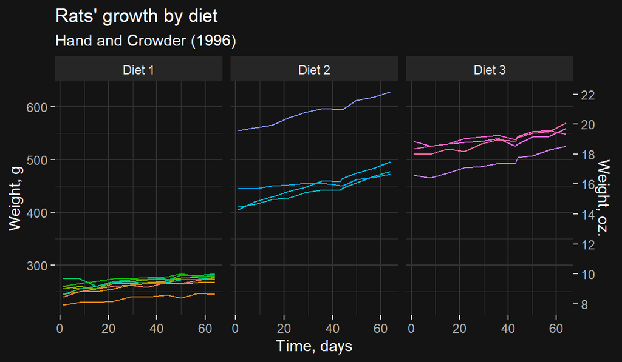

```r
# Plot individual rat data
RATSL %>%
  ggplot(aes(x = WD, y = Weight, color = ID)) +
  geom_line() +
  theme(legend.position = "none") +
  facet_grid(. ~ Group) +
  scale_y_continuous( # Ounces for US folks :D
    "Weight, g",
    sec.axis = sec_axis(~ . / 28.35, breaks = seq(0, 100, 2), name = "Weight, oz.")
  ) + labs(title = "Rats' growth by diet", subtitle = "Hand and Crowder (1996)") + xlab("Time, days")
```

The **control rats** (`Diet 1`) seem to have low weight to begin with and not much growth. **Diet 2** appears to have higher baseline weight, more growth and **a clear outlier (rat n:o 12)**, which is much heavier than any other rat. Rats on **Diet 3** may have even higher baseline weight, but the growth seems similar to rats on Diet 2.

### Tracking

Lets standardize the Weight variable by group:

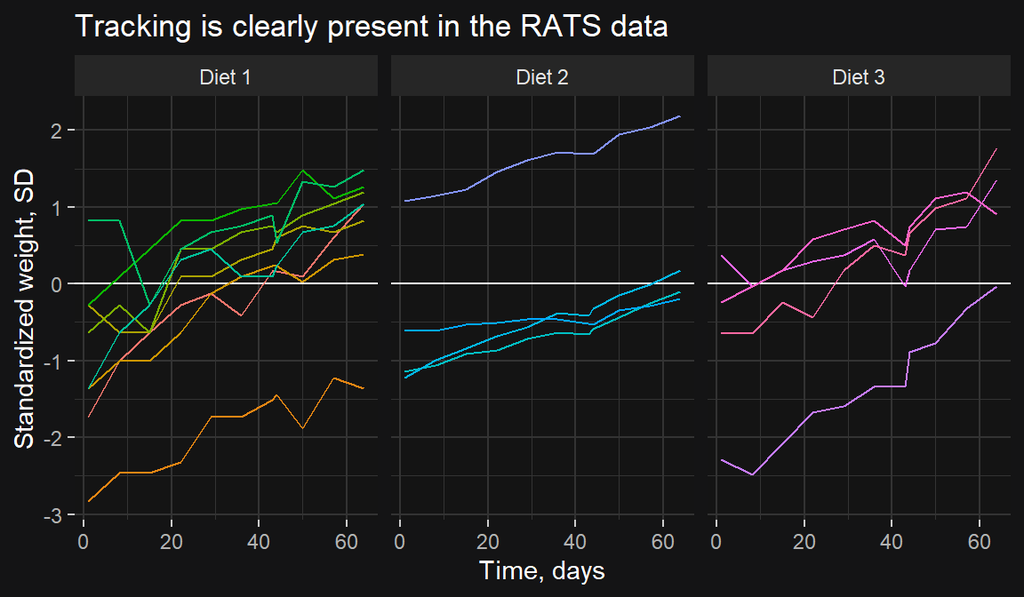

```r
RATSL %>%
  group_by(Group) %>% mutate(Weight_std = scale(Weight)[, 1]) %>% ungroup() %>%
  ggplot(aes(x = WD, y = Weight_std, color = ID)) +
  geom_hline(yintercept = 0) +
  geom_line() +
  theme(legend.position = "none") +
  facet_grid(. ~ Group) +
  ggtitle("Tracking is clearly present in the RATS data") + xlab("Time, days") + ylab("Standardized weight, SD")
```

There is considerable tracking: rats with higher baseline weight tend to have higher weight throughout the study.

### Tendencies

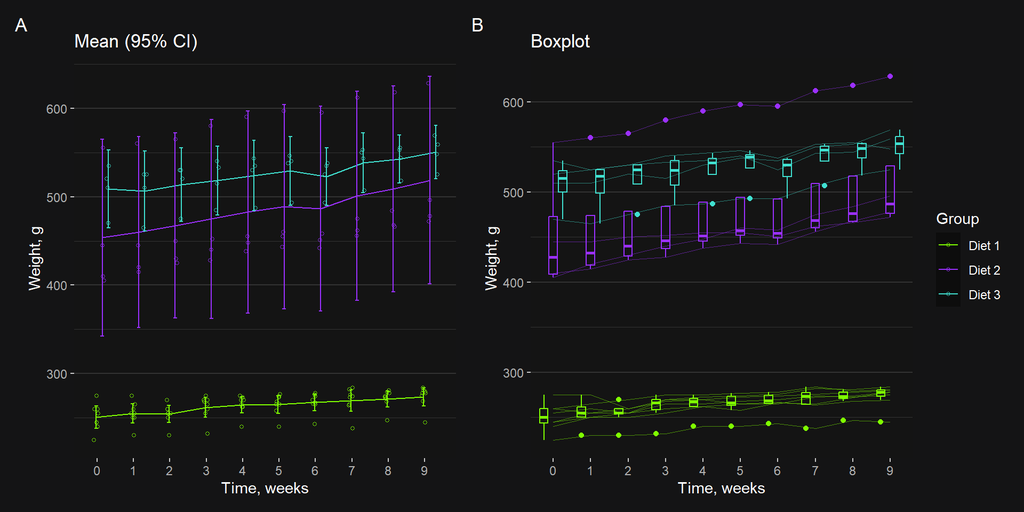

```r
dodge <- position_dodge(.5)
mypalette <- c("chartreuse", "purple1", "turquoise")

# Mean (95% confidence intervals)
p <- RATSL %>%
  filter(WD != 44) %>%
  ggplot(aes(x = WD / 7, y = Weight, color = Group))
p <- p + geom_point(
  shape = 21, size = 1, alpha = .8,
  position = position_jitterdodge(jitter.width = .3, dodge.width = .5)
)
p <- p + stat_summary(fun = mean, geom = "line", position = dodge)
p <- p + stat_summary(
  fun.data = mean_cl_normal, geom = "errorbar", position = dodge, width = .3
)
p <- p + theme(
  panel.grid.major.x = element_blank(),
  panel.grid.minor.x = element_blank()
)
p <- p + scale_color_manual(values = mypalette)
p <- p + scale_x_continuous(name = "Time, weeks", breaks = seq(0, 10, by = 1))
p <- p + scale_y_continuous(name = "Weight, g")
p <- p + ggtitle("Mean (95% CI)")
p1 <- p

# Boxplot visualization
p <- RATSL %>%
  filter(WD != 44) %>%
  ggplot(aes(x = (WD / 7) %>% round() %>% factor, y = Weight, color = Group))
p <- p + geom_line(
  aes(group = ID), linewidth = .2, alpha = .5
)
p <- p + geom_boxplot(fill = NA)
p <- p + theme(
  panel.grid.major.x = element_blank(),
  panel.grid.minor.x = element_blank(),
  legend.position = "none"
)
p <- p + scale_color_manual(values = mypalette)
p <- p + xlab("Time, weeks") + ylab("Weight, g")
p <- p + ggtitle("Boxplot")
p2 <- p

patchwork::wrap_plots(p1, p2) +
  patchwork::plot_layout(guides = "collect") +
  patchwork::plot_annotation(tag_levels = 'A')
```

**Plot A** shows that confidence intervals are wide in diet 2 due to large inter-rat variation. This might be because of an outlier identified in **plot B** (rat n:o 12). Other diets also have outliers (lighter rats) but these are not so extreme that they would considerably widen the CI’s. Group sizes are very small and it may affect the results if we further remove outliers.

### Compare means

Now let’s remove the outlier from group 2 and make data frame that we can use to compare the changes between groups.

```r
# Calculate average weights on the intervention
RATSLint <- RATSL %>%
  filter(WD > 1) %>%
  group_by(Group, ID) %>%
  reframe(mean_int = mean(Weight)) %>%
  mutate( # Add baseline weight
    baseline = RATSL %>% filter(WD == 1) %>% pull(Weight),
    delta = mean_int - baseline
  )
```

Plot the data:

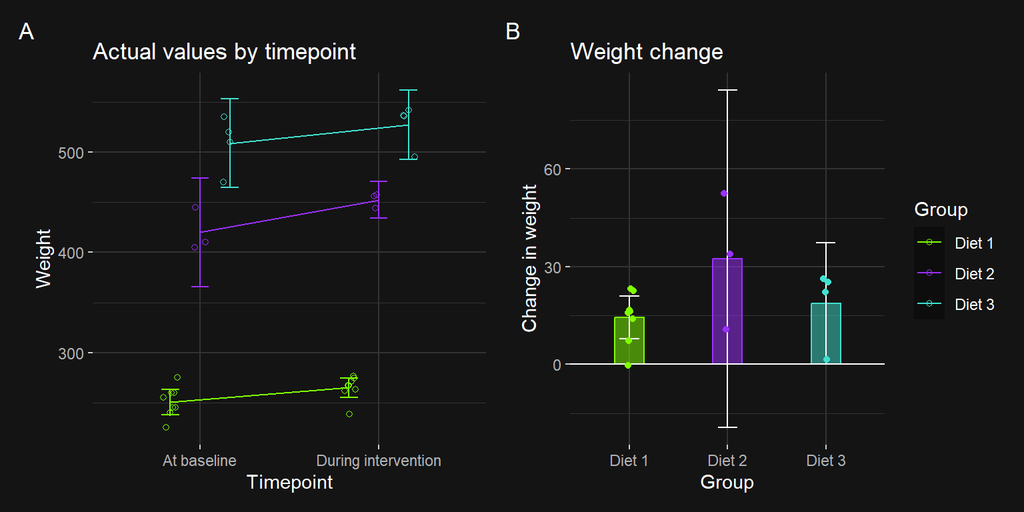

```r
# Plot baseline and intervention means
p1 <- RATSLint %>%
  filter(ID != 12) %>%
  pivot_longer(
  cols = c(baseline, mean_int),
  names_to = "Timepoint",
  values_to = "Weight"
  ) %>%
  mutate(Timepoint = recode(
    Timepoint,
    "baseline" = "At baseline",
    "mean_int" = "During intervention"
  )) %>%
  ggplot(aes(x = Timepoint, y = Weight, color = Group)) +
  geom_point(
    shape = 21,
    position = position_jitterdodge(jitter.width = .2, dodge.width = .5)
  ) +
  stat_summary(fun = mean, geom = "line", position = dodge, aes(group = Group)) +
  stat_summary(
  fun.data = mean_cl_normal, geom = "errorbar", position = dodge, width = .3
) +
  scale_color_manual(values = mypalette) +
  ggtitle("Actual values by timepoint")

# Delta variables
p2 <- RATSLint %>%
  filter(ID != 12) %>%
  ggplot(aes(x = Group, y = delta, color = Group, fill = Group)) +
  stat_summary(
    fun = mean, geom = "col", aes(group = Group), alpha = .5, width = .3
  ) +
  geom_hline(yintercept = 0) +
  stat_summary(
    fun.data = mean_cl_normal, geom = "errorbar", width = .2, color = "white"
  ) +
  geom_point(
    position = position_jitterdodge(jitter.width = .2, dodge.width = .5)
  ) +
  theme(legend.position = "none") +
  scale_color_manual(values = mypalette) +
  scale_fill_manual(values = mypalette) +
  ylab("Change in weight") + ggtitle("Weight change")

# Combine plots
patchwork::wrap_plots(p1, p2) +
  patchwork::plot_layout(widths = c(1, .8), guides = "collect") +
  patchwork::plot_annotation(tag_levels = 'A')
```

**Panel A** shows that all diet groups exhibit some kind of weight increase from baseline. This increase appears to be the strongest on `Diet 2`. However, from **panel B** we see that there may be too few rats on `Diet 2` to draw strong conclusions about their weight change, as the CI is very wide and includes 0. We also cannot just look at delta variables because there is massive differences in baseline weight between rat groups.

### Significance

```r
# Fit the model
# fit_full <- lm(mean_int ~ baseline + Group, data = RATSLint)
fit_excl <- lm(mean_int ~ baseline + Group, data = RATSLint %>% filter(ID != 12))

# fit_full %>% gtsummary::tbl_regression()
fit_excl %>% gtsummary::tbl_regression()
```

| **Characteristic** | **Beta** | **95% CI**<sup>1</sup> | **p-value** |
| --- | --- | --- | --- |
| baseline | 0.58 | 0.30, 0.85 | <0.001 |
| Group |  |  |  |
| Diet 1 | — | — |  |
| Diet 2 | 89 | 41, 138 | 0.002 |
| Diet 3 | 113 | 41, 185 | 0.005 |

<sup>1</sup> CI = Confidence Interval

```r
# See anova tables
# anova(fit_full)
anova(fit_excl)
```

```
## Analysis of Variance Table
##
## Response: mean_int
##           Df Sum Sq Mean Sq   F value    Pr(>F)
## baseline   1 207817  207817 2714.9357 1.601e-14 ***
## Group      2   1483     742    9.6878  0.003748 **
## Residuals 11    842      77
## ---
## Signif. codes:  0 '***' 0.001 '**' 0.01 '*' 0.05 '.' 0.1 ' ' 1
```

```r
# Confirm using repeated measures ANOVA
RATSL %>%
  filter(ID != 12) %>%
  rstatix::anova_test(
    dv = Weight, wid = ID, within = WD, between = Group
  ) %>%
  rstatix::get_anova_table()
```

```
## ANOVA Table (type III tests)
##
##     Effect  DFn   DFd       F        p p<.05   ges
## 1    Group 2.00 12.00 483.599 3.39e-12     * 0.986
## 2       WD 1.85 22.24  54.668 4.24e-09     * 0.404
## 3 Group:WD 3.71 22.24   4.495 9.00e-03     * 0.100
```

## 6.2 BPRS

Briefly checking the data structure.

```r
str(BPRSL)
```

```
## tibble [360 × 4] (S3: tbl_df/tbl/data.frame)
##  $ treatment: Factor w/ 2 levels "Treatment 1",..: 1 1 1 1 1 1 1 1 1 1 ...
##  $ subject  : Factor w/ 20 levels "1","2","3","4",..: 1 1 1 1 1 1 1 1 1 2 ...
##  $ week     : num [1:360] 0 1 2 3 4 5 6 7 8 0 ...
##  $ bprs     : num [1:360] 42 36 36 43 41 40 38 47 51 58 ...
```

There are 40 male participants randomized equally to 2 interventions ($n = 20$ each).

```r
# N's
BPRSL %>%
  filter(week == 0) %>%
  {table(.$treatment)}
```

```
##
## Treatment 1 Treatment 2
##          20          20
```

First it will be helpful to plot all data and observe any obvious big patterns.

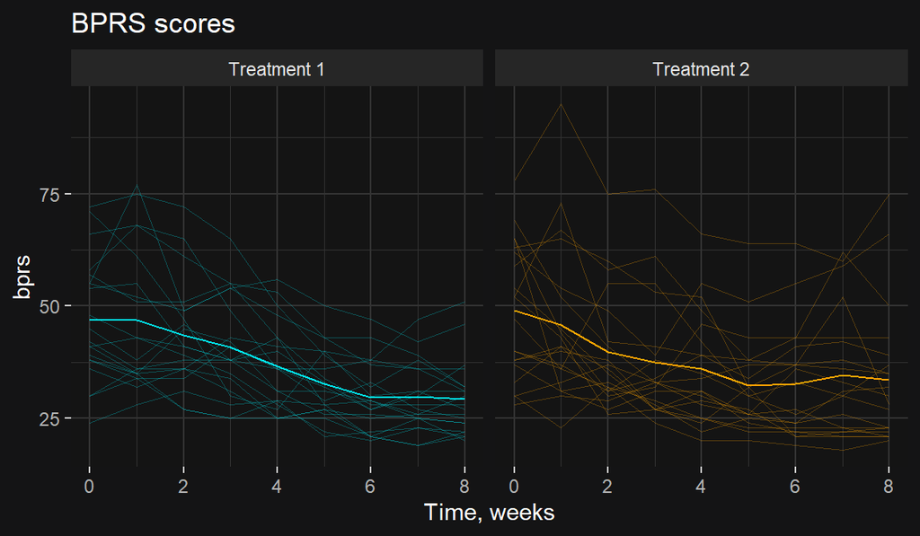

```r
bprs_pal <- \ (x) {scale_color_manual(values = c("turquoise2", "orange"))}
# Plot individual rat data
BPRSL %>%
  ggplot(aes(x = week, y = bprs, group = subject, color = treatment)) +
  geom_line(alpha = .3, linewidth = .2) +
  stat_summary(fun = "mean", geom = "line", aes(group = treatment)) +
  theme(legend.position = "none") +
  facet_grid(. ~ treatment) +
   labs(title = "BPRS scores") + xlab("Time, weeks") + bprs_pal()
```

Clearly there is a lot of variation between and within subjects. Both treatments show decreasing mean `bprs` score across time.

Whether these trends are statistically significant or even differ between treatments is yet unknown. These questions are best answered using *linear mixed models*.

```r
# Run time of this chapter code
end.time <- Sys.time(); elapsed.time <- (end.time - start.time) %>% round()
elapsed.time
```

```
## Time difference of 9 secs
```